# Deep Learning: Implementation

**Purpose:** The previous two notebooks have discussed theoretical and foundational aspects of deep learning models. In particular, what types of architectures and activation functions exist (and, to a lesser extent, how do I choose one). In this notebook our goal will be to actually build, assess, and utilize a deep learning network for image classification.

## Data and Modeling

Since you set up TensorFlow in an earlier notebook, let’s load `{reticulate}` in an R code chunk and then import `{tensorflow}`, `{keras}`, using a python chunk.We’ll use the Fashion MNIST data set, so we’ll load that as well. You can learn more about that data set from [its official repository here](https://github.com/zalandoresearch/fashion-mnist).

```r
library(reticulate)
```

```python
import pandas as pd
import numpy as np
import matplotlib.pyplot as plt
import tensorflow as tf
from keras.datasets import fashion_mnist
from keras.models import Sequential
from keras.layers import Flatten, Dense, Dropout, Lambda

(x_train, y_train), (x_test, y_test) = fashion_mnist.load_data()

x_train = x_train/255
x_test = x_test/255

labels_df = pd.DataFrame({
  "label" : range(10),
  "item" : ["Tshirt", "Trousers", "Pullover", "Dress", "Coat", "Sandal", "Shirt", "Sneaker", "Bag", "AnkleBoot"]
  })
```

Let’s take a look at a few items and their labels.

```python
item_num = 4

print("Item is: ", labels_df.loc[labels_df["label"] == y_train[item_num], "item"])
```

```
## Item is:  0    Tshirt
## Name: item, dtype: object
```

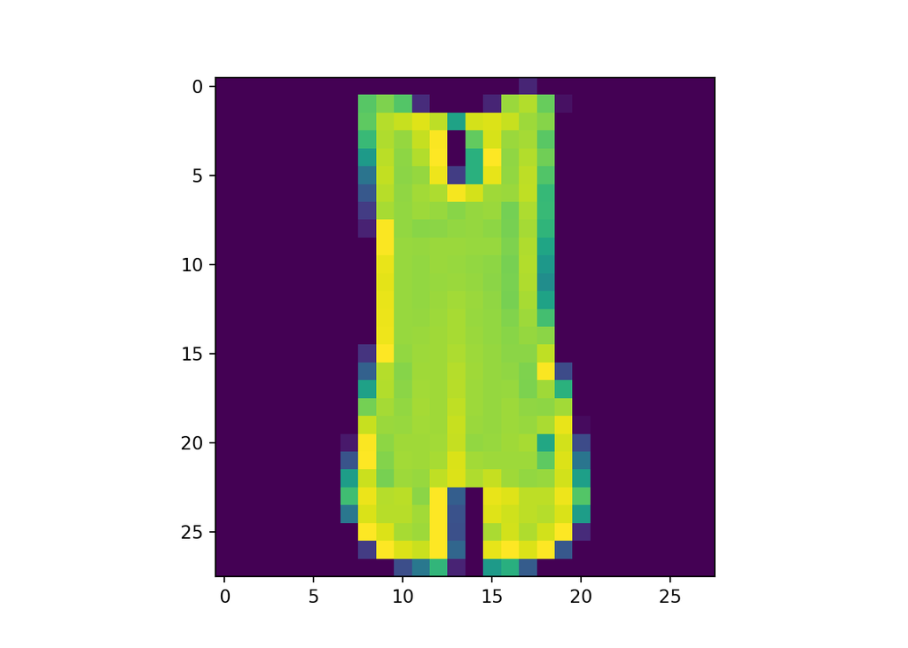

```python
plt.imshow(x_train[item_num, :, :])
plt.show()
```

Okay – I’m having a difficult time identifying some of these items. Can we train a sequential neural network to learn the classes?

```python
model = Sequential([
  Flatten(input_shape = (28,28)),
  Dense(128, activation = "relu"),
  Dropout(0.2),
  Dense(10, activation = "softmax")
])

model.summary()
```

```
## Model: "sequential"
## _________________________________________________________________
##  Layer (type)                Output Shape              Param #
## =================================================================
##  flatten (Flatten)           (None, 784)               0
##
##  dense (Dense)               (None, 128)               100480
##
##  dropout (Dropout)           (None, 128)               0
##
##  dense_1 (Dense)             (None, 10)                1290
##
## =================================================================
## Total params: 101770 (397.54 KB)
## Trainable params: 101770 (397.54 KB)
## Non-trainable params: 0 (0.00 Byte)
## _________________________________________________________________
```

We have a model with over 100,000 parameters! Because random weights are initially set for each of these, we can use the model straight “out of the box” for prediction. We shouldn’t expect the network to perform very well though.

```python
predictions = model.predict(x_train[:2, :, :])
#Predictions as a vector of log-odds
predictions
#Predictions as class-membership probabilities
```

```
## array([[0.10245589, 0.08768913, 0.12370513, 0.18182682, 0.08118267,
##         0.0402923 , 0.23050708, 0.05350573, 0.04104901, 0.05778628],
##        [0.0975403 , 0.11283207, 0.0658805 , 0.2278418 , 0.04386355,
##         0.05245278, 0.11948042, 0.16097698, 0.04762336, 0.07150826]],
##       dtype=float32)
```

```python
tf.nn.softmax(predictions)
```

```
## <tf.Tensor: shape=(2, 10), dtype=float32, numpy=
## array([[0.10006306, 0.0985963 , 0.10221207, 0.10832884, 0.09795687,
##         0.09403217, 0.11373278, 0.0952829 , 0.09410335, 0.09569164],
##        [0.09959807, 0.1011328 , 0.09649421, 0.1134593 , 0.09439291,
##         0.09520716, 0.10180741, 0.10612094, 0.09474847, 0.09703878]],
##       dtype=float32)>
```

Let’s define a loss function so that we can train the model by optimizing the loss.

```python
y_train_wide = np.zeros((len(y_train), 10))

for i in range(len(y_train)):
  label = y_train[i]
  y_train_wide[i, label] = 1

predictions
```

```
## array([[0.10245589, 0.08768913, 0.12370513, 0.18182682, 0.08118267,
##         0.0402923 , 0.23050708, 0.05350573, 0.04104901, 0.05778628],
##        [0.0975403 , 0.11283207, 0.0658805 , 0.2278418 , 0.04386355,
##         0.05245278, 0.11948042, 0.16097698, 0.04762336, 0.07150826]],
##       dtype=float32)
```

```python
y_train_wide[:2, :]
```

```
## array([[0., 0., 0., 0., 0., 0., 0., 0., 0., 1.],
##        [1., 0., 0., 0., 0., 0., 0., 0., 0., 0.]])
```

```python
loss_fn = tf.keras.losses.CategoricalCrossentropy()
loss_fn(y_train_wide[:2], predictions)
```

```
## <tf.Tensor: shape=(), dtype=float32, numpy=2.5892467>
```

Before training, we’ll need to set the optimizer, assign the loss function, and define the performance metric. We’ll then compile the model with these attributes.

```python
model.compile(optimizer = "adam", loss = loss_fn, metrics = ["accuracy"])
```

Since the model has been compiled, we are ready to train it. This network has an output layer consisting of 10 neurons (one for each class). Because of this, we’ll need a response which is of the same shape – that is we need a binary matrix whose rows contain a 1 in exactly one position, denoting the class of the corresponding training record. We have this in `y_train_wide`.

```python
model.fit(x_train, y_train_wide, epochs = 5)
```

```
##
##
##
##
##
## <keras.src.callbacks.History object at 0x000001A3DA576B30>
```

Now let’s evaluate our model performance.

```python
y_test_wide = np.zeros((len(y_test), 10))

for i in range(len(y_test)):
  label = y_test[i]
  y_test_wide[i, label] = 1

score = model.evaluate(x_test, y_test_wide)
score
```

```
## [0.3695288896560669, 0.8650000095367432]
```

Since our model has been trained, we can use it to make predictions again.

```python
predictions = model.predict(x_test[1:5, :, :])
tf.nn.softmax(predictions)
```

```
## <tf.Tensor: shape=(4, 10), dtype=float32, numpy=
## array([[0.08541211, 0.08541188, 0.2307762 , 0.08541188, 0.08544528,
##         0.08541188, 0.0858952 , 0.08541188, 0.08541188, 0.08541188],
##        [0.08533675, 0.2319693 , 0.08533674, 0.08533675, 0.08533674,
##         0.08533674, 0.08533674, 0.08533674, 0.08533674, 0.08533674],
##        [0.08533683, 0.23196799, 0.08533682, 0.08533739, 0.08533682,
##         0.08533682, 0.08533682, 0.08533682, 0.08533682, 0.08533682],
##        [0.09722714, 0.08779798, 0.09837112, 0.08825789, 0.08933015,
##         0.08779713, 0.18763044, 0.08779696, 0.08799417, 0.087797  ]],
##       dtype=float32)>
```

We can update our model so that it will provide class predictions rather than just the class membership probabilities.

```python
class_model = Sequential([
  model,
  Lambda(lambda x: tf.argmax(x, axis = -1))
])

class_model.predict(x_test[1:5, :, :])
```

```
##
## array([2, 1, 1, 6], dtype=int64)
```

Now that we’ve trained an assessed one neural network, go back and change your model. Add hidden layers to make it a true deep learning model. Experiment with the dropout rate or activation functions. Just remember that you’ll need 10 neurons in your output layer since we have 10 classes and that the activation function used there should remain `softmax` since we are working on a multiclass classification problem. Everything else (other than the input shape) is fair game to change though!

## Summary

In this notebook we installed and used TensorFlow from R to build and assess a shallow learning network to classify clothing items from very pixelated images. The images were $28\times 28$. We saw that even a “simple” neural network was much better at predicting the class of an item based off of its pixelated image than we are as humans.